# Hpgltools examples using a small bacterial data set.

# Performing DE analyses

This is a relatively small data set, so performing some differential expression analyses really should not take long at all.

When performing these analyses with hpgltools, it will attempt to perform similar analyses with limma, edgeR, and DESeq2 via the all_pairwise() function. The most likely argument is ‘model_batch’ which may be used to explicitly include/exclude a batch factor in the model, or ask it to attempt including batch factors from sva/ruv/etc. By default it will attempt to include a column from the experimental design named ‘batch’.

```r
spyogenes_de <- sm(all_pairwise(expt))
```

[output not shown]

```r
## Even the lowest correlations are quite high.
```

[output not shown]

[output not shown]

Working with these separate tables can be more than a little annoying, combine_de_tables() attempts to simplify this. It will bring together the various tables, and if asked attempt to bring them together into a pretty-ified excel workbook.

all_pairwise() arbitrarily performs all possible pairwise comparisons. This is not necessarily what one actually wishes to see. Therefore, the argument keepers takes a list of contrasts:

```r
my_keepers <- list(
    "wt_media" = c("wt_ll_cf", "wt_ll_cg"),
    "mga_media" = c("mga_ll_cf", "mga_ll_cg"))
```

Because these tables can get quickly extremely large, the excel workbooks may become too big for the zip(1) program to properly merge. If that happens, one may either remove some(or all) of the plots and/or have it print csv versions of the same tables.

```r
spyogenes_tables <- sm(combine_de_tables(spyogenes_de))
```

[output not shown]

```r
summary(spyogenes_tables)
```

[output not shown]

Finally, extract_significant_genes() may choose ‘significant’ genes based upon a few metrics including z-score vs. the distribution of logFC; a logFC cutoff, (ajusted)p-value cutoff, and/or top/bottom n genes.

```r
spyogenes_sig <- sm(extract_significant_genes(spyogenes_tables))
```

[output not shown]

```r
knitr::kable(head(spyogenes_sig$limma$ups[[1]]))
```

[output not shown]

# Make pretty circos graphs

Since most of my circos graphs are for pyogenes, it is likely that the defaults are appropriate for this particular organism.

Much(all) of the following is taken from the material in tests/testthat/test_70mga.R

```r
microbe_ids <- as.character(get_microbesonline_ids("pyogenes MGAS5005"))
```

```
## SELECT taxonomyId, shortName FROM Taxonomy WHERE shortName like '%pyogenes MGAS5005%'
```

```r
mgas_df <- sm(get_microbesonline_annotation(microbe_ids[[1]])[[1]])
mgas_df$sysName <- gsub(pattern="Spy_", replacement="Spy", x=mgas_df$sysName)
rownames(mgas_df) <- make.names(mgas_df$sysName, unique=TRUE)

## First make a template configuration
circos_test <- sm(circos_prefix())
## Fill it in with the data for s.pyogenes
circos_kary <- sm(circos_karyotype("mgas", length=1895017))
## Fill in the gene category annotations by gene-strand
circos_plus <- sm(circos_plus_minus(mgas_df, circos_test))

circos_limma_hist <- sm(circos_hist(spyogenes_de$limma$all_tables[[1]], mgas_df, circos_test, outer=circos_plus))
```

[output not shown]

```r
circos_deseq_hist <- sm(circos_hist(spyogenes_de$deseq$all_tables[[1]], mgas_df, circos_test, outer=circos_limma_hist))
```

[output not shown]

```r
circos_edger_hist <- sm(circos_hist(spyogenes_de$edger$all_tables[[1]], mgas_df, circos_test, outer=circos_deseq_hist))
```

[output not shown]

```r
circos_suffix(cfgout=circos_test)
circos_made <- sm(circos_make(target="mgas"))
## For some reason this fails weirdly when not run interactively.
```

[figure not shown]

GenoplotR is new to me, but it seems to work?

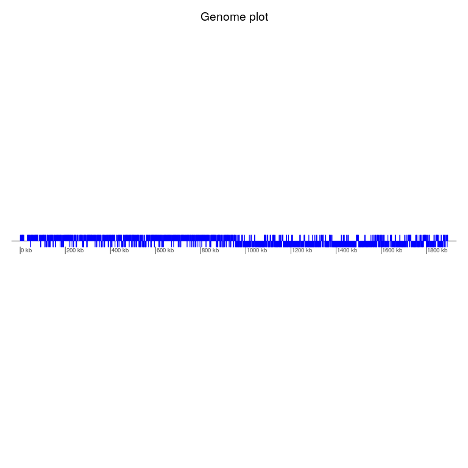

```r
genoplot_chromosome()
```

**R version 3.3.1 (2016-06-21)**

**Platform:** x86_64-pc-linux-gnu (64-bit)

**locale:** *LC_CTYPE=en_US.UTF-8*, *LC_NUMERIC=C*, *LC_TIME=en_US.UTF-8*, *LC_COLLATE=en_US.UTF-8*, *LC_MONETARY=en_US.UTF-8*, *LC_MESSAGES=en_US.UTF-8*, *LC_PAPER=en_US.UTF-8*, *LC_NAME=C*, *LC_ADDRESS=C*, *LC_TELEPHONE=C*, *LC_MEASUREMENT=en_US.UTF-8* and *LC_IDENTIFICATION=C*

**attached base packages:** *stats*, *graphics*, *grDevices*, *utils*, *datasets* and *base*

**other attached packages:** hpgltools(v.2016.02)

**loaded via a namespace (and not attached):** *Rcpp(v.0.12.7)*, *knitr(v.1.14)*, *magrittr(v.1.5)*, *BiocGenerics(v.0.19.2)*, *devtools(v.1.12.0)*, *doParallel(v.1.0.10)*, *munsell(v.0.4.3)*, *colorspace(v.1.2-6)*, *R6(v.2.1.3)*, *foreach(v.1.4.3)*, *stringr(v.1.1.0)*, *plyr(v.1.8.4)*, *tools(v.3.3.1)*, *parallel(v.3.3.1)*, *grid(v.3.3.1)*, *Biobase(v.2.33.1)*, *gtable(v.0.2.0)*, *DBI(v.0.5-1)*, *withr(v.1.0.2)*, *iterators(v.1.0.8)*, *htmltools(v.0.3.5)*, *ade4(v.1.7-4)*, *RMySQL(v.0.10.9)*, *yaml(v.2.1.13)*, *digest(v.0.6.10)*, *crayon(v.1.3.2)*, *RColorBrewer(v.1.1-2)*, *ggplot2(v.2.1.0)*, *formatR(v.1.2.1)*, *bitops(v.1.0-6)*, *codetools(v.0.2-14)*, *RCurl(v.1.95-4.7)*, *testthat(v.1.0.2)*, *memoise(v.1.0.0)*, *evaluate(v.0.9)*, *rmarkdown(v.1.0)*, *stringi(v.1.1.1)*, *pander(v.0.6.0)*, *genoPlotR(v.0.8.4)*, *methods(v.3.3.1)* and *scales(v.0.4.0)*